# hanqin_group_lasso

Hanqin Du

2020/1/11

## Up date aims

##### Quantify the effect of cis-regulatory elements under different environmental stress by fitting linear models with group lasso

To investigate and quantify how the cis-regulatory element affects the gene regulation, we built a series of linear models where each model takes the frequencies of cis-regulatory elements as input and predicts how the gene expression level under certain environmental stress. Their coefficient can be used to estimate the regulatory effect of both a single cis-regulatory element or all the cis-regulatory as a group. For example, if an element is given a relatively large coefficient in a model which predicts the change of expression level under certain environmental stress, we can say the element play a relatively important role in the regulation under that environmental stress. On the other hand, the bias of the model can be considered as the expected gene expression level change of a gene with no cis-regulatory element we considered in the model. In other words, the bias indicates the expression level change that cannot be explained by the model and can be used to estimate the proportion of the efforts on regulation these cis-regulatory elements make.

At this stage, our aim is to apply group lasso as a multi-task learning method to training all the models together which allows the comparison across each model and ensures their generalization. The L2 penalty term can filter out most of the irrelevant factors by penalizing their coefficient close to zero.

The penalty on the coefficient vector for variable j is:
$$(1-\alpha)/2||\beta_j||_2^2+\alpha||\beta_j||_2.$$

## import data

##### Expression level change of 6152 distinct genes under 173 different environmental stresses from Gasch’s study

In this project, we apply the data describes gene expression level in various environment condition from Gasch’s study `Genomic Expression Programs in the Response of Yeast Cells to Environmental Changes`. To figure out how the expression level change, DNA microarrays were used:

> DNA microarrays were used to measure changes in transcript levels over time for almost every yeast gene, as cells responded to temperature shocks, hydrogen peroxide, the superoxide-generating drug menadione, the sulfhydryl-oxidizing agent diamide, the disulfide-reducing agent dithiothreitol, hyper- and hypo-osmotic shock, amino acid starvation, nitrogen source depletion, and progression into stationary phase.

DNA microarray, also know as DNA chips or biochip, is a collection of microscopic DNA spots attached to a solid surface. Each DNA spot contains picomoles (10−12 moles) of a specific DNA sequence which can a short section of a gene or other DNA element that are used to hybridize a cDNA or cRNA (also called anti-sense RNA). To measure the gene expression level in different environment, both the cells under environment stress and unstressed reference cells were collected by centrifugation (at 3000 3g for 3 to 7 min at room temperature), suspended (in 3 to 10 ml of lysis buffer and stored at 280°C) until RNA preparation. Then the mRNA was purified (using oligo-dT cellulose) precipitated and resuspended (in Tris-EDTA (TE) at a final concentration of 0.5–1 mg/mL). (Gasch et al., 2000)

##### 69 sequence motifs found on RNA untranslated region from 3 different studies

The 69 sequence motifs we use in this project is from 3 different studies:

51 of them come from the study of Shalgi et al (2005) names `A catalog of stability-associated sequence elements in 3' UTRs of yeast mRNAs`. These motifs are found by analyzing the 3’UTR and mRNA decay rate:

> By analyzing 3’ UTR sequences and mRNA decay profiles of Saccharomyces cerevisiae genes, we derived a catalog of 53 sequence motifs that may be implicated in stabilization or destabilization of mRNAs.

14 of them come from the study of Hogan et al. (2008): `Diverse RNA-Binding Proteins Interact with Functionally Related Sets of RNAs, Suggesting an Extensive Regulatory System`. By studying the effect of RBPs, some of the sequence motifs that are likely to be the binding sites of 16 of the RBPs are figured out.

> For 16 of the 40 RNA binding proteins, we identified sequence motifs significantly enriched in their RNA targets that presumably mediate recognition of the target by the RBP.

The rest 4 are from study of Cheng (2017): `Cis-regulatory elements explain most of the mRNA stability variation across genes in yeast`, a study quantitatively delineates the contributions of mRNA sequence features on stability in yeast by building a model for Saccharomyces cerevisiae based on functional mRNA sequence.

##### UTR sequence of 4388 genes from Sun et al. (2013)

UTR sequence of 4388 genes are obtained from Sun, M. et al. (2013) ‘Global analysis of Eukaryotic mRNA degradation reveals Xrn1-dependent buffering of transcript levels’.

## Load Data

Load 69 published motifs (from Abhi’s report) and 3’UTR sequences of 4388 different genes. Then, Load Gasch’s gene-expression-level data which describes the relative gene expression level under 173 different environment conditions among 6152 genes.

##### Construct Motif Frequencies Matrix from 3’UTR Ref sequences

By converting all the motifs to regular expression, we are able to construct motifs frequency matrix which describes the frequency of 69 motifs among 4388 different genes.

##### Merge motif frequency matrix with Gasch’s data

Finally, we inner join the motif frequency matrix with Gasch’s data and get the data frame we are going to explore. Each row represented data from one of the 4284 genes (since we have carried out inner join, only the genes shown in both tables are kept). There are 245 columns in total. 3 of them describe the basic information (short and formal name) of the gene represented by the row. 173 of them show how the gene expression level change under the certain environment condition and the other 69 of them respect the frequency of the 69 published motifs on the 3’UTR.

##### Remove motifs with frequency 0

## investigate the missing value

##### 3% of the expression level data microarray are missing

We noticed that, above all the expression level data, around 3% of them are missing value, Where most of the genes (94.8%) have a relatively complete expression levels’ data (90%) while 41 genes (0.7%) have missing valves under more than quarter of environmental stresses.

| number of genes | missing value (n) |
| --- | --- |
| 755 (12.3%) | 0 |
| 5073 (82.5%) | 0 < n < 18 |
| 283 (4.6%) | 17 < n < 44 |
| 41 (0.7%) | 43 < n < 100 |

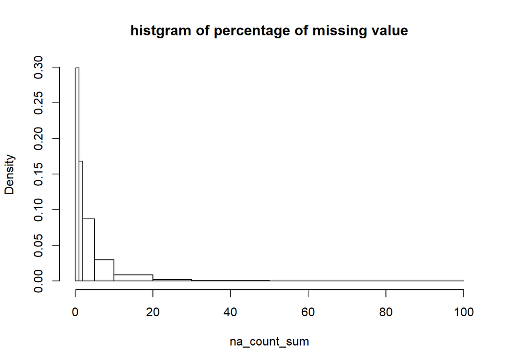

##### (1) replace missing value with 0

As one of the easiest way to deal with the missing values, we could simply replace them by 0

```r
fullTable_Gasch_na2zero = fullTable_Gasch
fullTable_Gasch_na2zero[is.na(fullTable_Gasch_na2zero)] <- 0.0
```

##### (2) carry out inputation to replace missing data with substituted values

Applying imputation to estimate the missing values should be a much better way rather than simply ignore the missing values or replacing them by mean or 0 since it reduce the bias. Olga Troyanskaya et al. suggest in their article `Missing value estimation methods for DNA microarrays` that weighted K-nearest neighbors (KNNimpute) could be another sensitive method to deal with the missing value

> We show that KNNimpute appears to provide a more robust and sensitive method for missing value estimation than SVDimpute, and both SVDimpute and KNNimpute surpass the commonly used row average method (as well as filling missing values with zeros).

According to Olga Troyanskaya et al., when we consider gene A that has one missing value under environmental stress X, we could look for how the expression level of gene A change in other environmental stress Y and looking for k other genes B that show similar behavior as gene A. Then we fill the missing value by the weighted average of genes B. The contribution of each gene is weighted by similarity of its expression to that of gene A.

```r
# unimplemented
```

## glmnet group lasso notes

##### basic idea about glmnet group lasso

reference:

defination of p-norm
$$||x||_p := (\sum ^n_{i=1}|x_i|^p)^{1\over p}$$

Glmnet is a package that fits a generalized linear model via penalized maximum likelihood. The regularization path is computed for the lasso or elasticnet penalty at a grid of values for the regularization parameter lambda.

$$\min_{\beta_0,\beta} \frac{1}{N} \sum_{i=1}^{N} w_i l(y_i,\beta_0+\beta^T x_i) + \lambda\left[(1-\alpha)||\beta||_2^2/2 + \alpha ||\beta||_1\right],$$

Where l(y,η) is the negative log-likelihood contribution for observation i. Accroding to the introduction of glmnet, the penalty on the coefficient vector for variable j is
$$(1-\alpha)/2||\beta_j||_2^2+\alpha||\beta_j||_1.$$

Setting `family="mgaussian"` allows a multi-response gaussian model to be fit, using a “group -lasso” penalty on the coefficients for each variable. Setting `type.multinomial="grouped"` allows the same penalty as `family="mgaussian"`, which is:
$$(1-\alpha)/2||\beta_j||_2^2+\alpha||\beta_j||_2.$$
when `alpha = 1` this is a group-lasso penalty, and otherwise it mixes with quadratic just like elasticnet. In group lasso, we summing all the penalty

##### compare L1 and L2

- L1 could have more than one optimal solution while L2 only has one
- L1 is more robust. no sensitive to extreme value
- L1 give more 0 to not important features (better for feature selection)
- L2 is easier to calculate

## multi-task learning on all 173 environmental stress

```r
names_condition = colnames(expressionLevel_Gasch, do.NULL = TRUE, prefix = "col")[4:176]

x = as.matrix(fullTable_Gasch_double[names_motifs_valid])
y = as.matrix(fullTable_Gasch_double[names_condition])

x[is.na(x)]<-0.0
y[is.na(y)]<-0.0

cv_models_all = cv.glmnet(x, y, family = "mgaussian")
```

##### pick lambda with 10-fold cross validation

`lambda.min` is the value of lambda that gives minimum cvm; `lambda.1se` is the largest value of lambda such that error is within 1 standard error of the minimum; The confidence intervals represent error estimates for the loss metric (red dots). They’re computed using cross validation. The vertical lines show the locations of λmin and λ1se. The numbers across the top are the number of nonzero coefficient estimates. The error is accumulated, and the average error and standard deviation over the folds is computed.

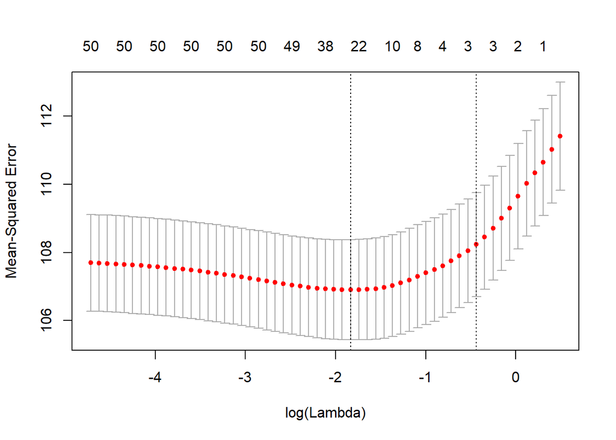

```r
plot(cv_models_all)
```

##### training models with the lambda value that gives minimum loss. a majority of coefficients are very close to 0, the effect of penalty is significant.

Here we let alpha=1 as default to achieve a group-lasso penalty, and otherwise it mixes with quadratic just like elasticnet.

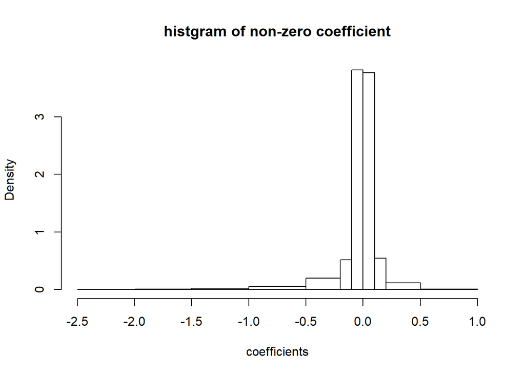

```r
coefficients = NULL
for (condition in names_condition) {
  coefficients = c(coefficients,models_all$beta[[condition]]@x)
}

hist(coefficients, breaks = c(-2.5,-2,-1.5,-1,-0.5,-0.2,-0.1,0,0.1,0.2,0.5,1), main = 'histgram of non-zero coefficient')
```

```r
count_nonzero_coefficient = 0

for (condition in names_environmental_stress) {
  count_nonzero_coefficient = count_nonzero_coefficient + models_all$beta[[condition]]@p[2]
}

count_all_coefficient = length(names_environmental_stress)*length(names_motifs_valid)

1 - (count_nonzero_coefficient/count_all_coefficient)
```

```
## [1] 0.46
```

##### coefficient shift to zero as the time after environmental stress increasing

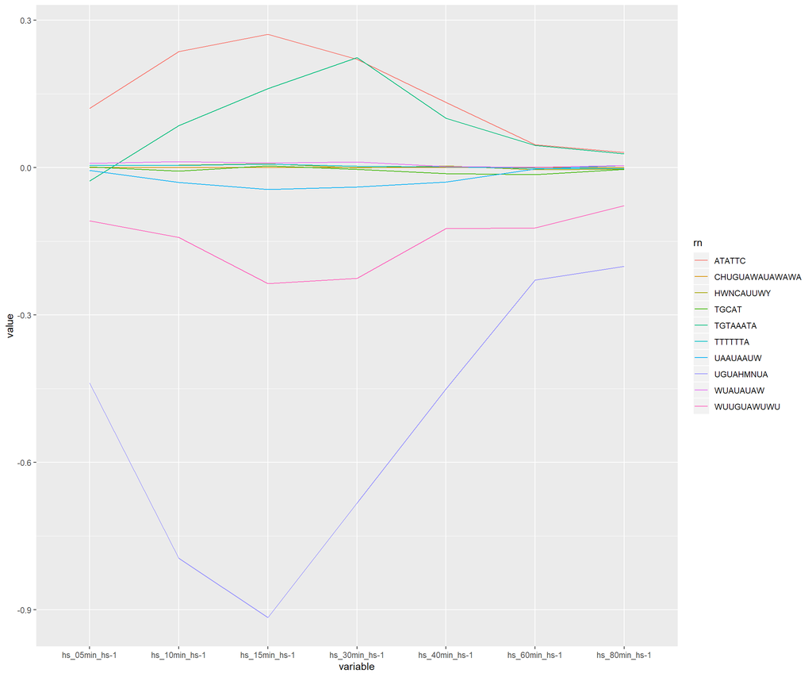

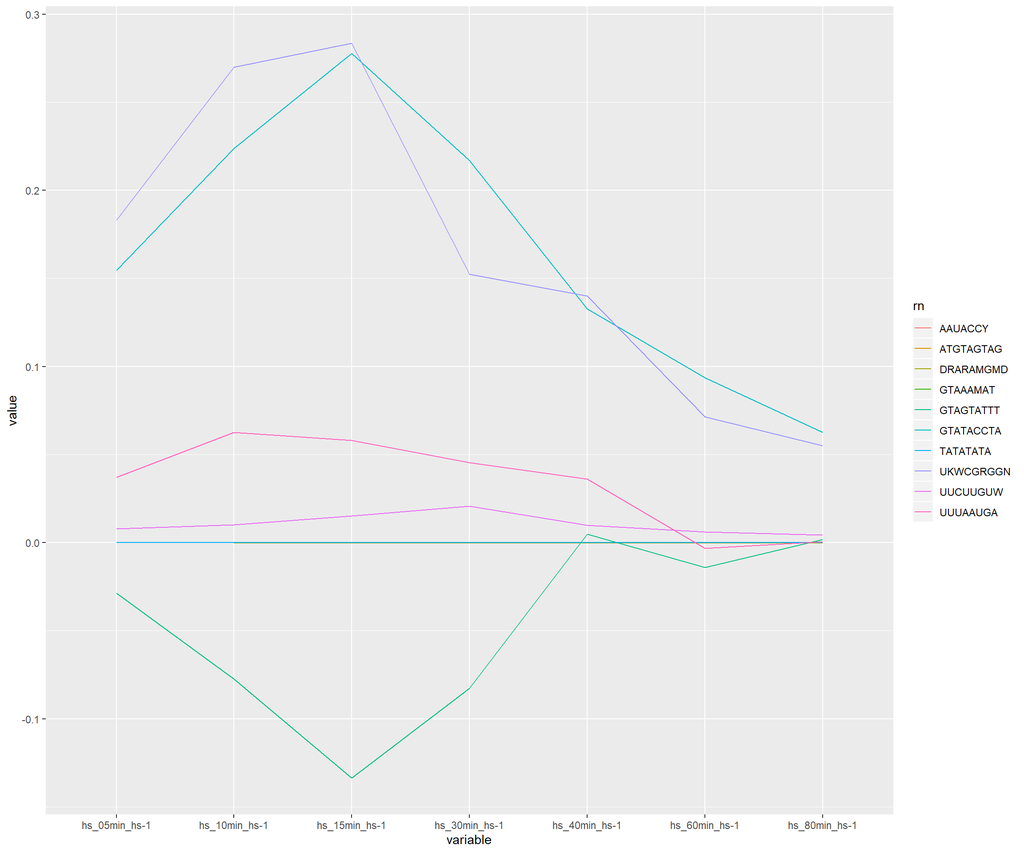

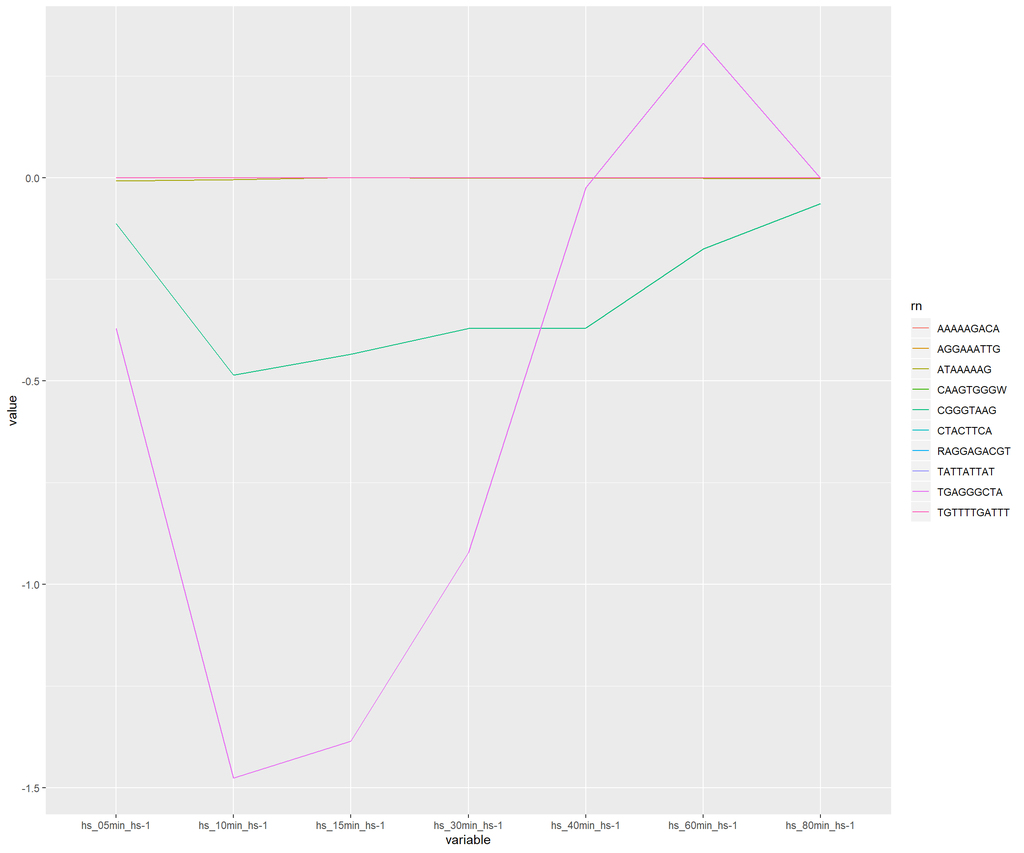

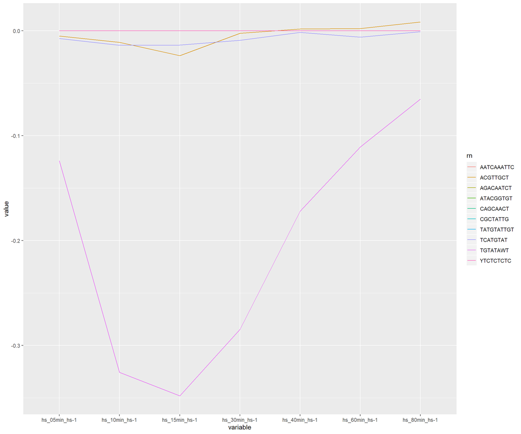

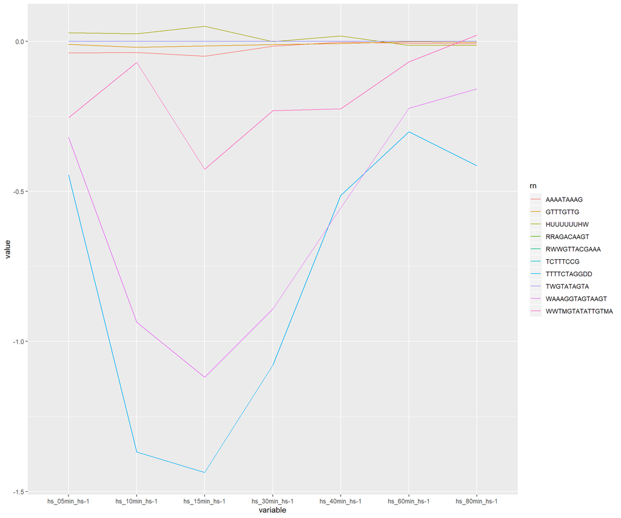

##### Analysis the Bias

The bias of each model shows the change of expression level that cannot be explained by these motifs here we calculate the percentage of it against the mean of change in expression level to estimate how much of the regulation effect cannot be expalined by the model. The estimation is base on many assumptions and could be very ambiguous.

$$bias\over mean( expression\ level)$$

```r
models_all$a0/colMeans(fullTable_Gasch_double[names_condition], na.rm = TRUE)
```

```
##                                                  s0
## hs_05min_hs-1                            0.79693228
## hs_10min_hs-1                            0.80924691
## hs_15min_hs-1                            0.71733639
## hs_20min_hs-1                            0.72167635
## hs_30min_hs-1                            0.64177425
## hs_40min_hs-1                            0.67959086
## hs_60min_hs-1                           -0.07654118
## hs_80min_hs-1                           -0.42139380
## hs_00min_hs-2                           -9.43521107
## hs_00min_hs-2_1                          0.98539535
## hs_00min_hs-2_2                          2.82780216
## hs_05min_hs-2                            1.08026458
## hs_15min_hs-2                           -0.41648906
## hs_30min_hs-2                           -7.85866513
## hs_60min_hs-2                            1.03558668
## hs_37to25_15min                          1.26648593
## hs_37to25_30min                          1.64558966
## hs_37to25_45min                          1.24838420
## hs_37to25_60min                          1.19312415
## hs_37to25_90min                         -4.60662907
## hs_17to37_20min                         -0.62511215
## hs_21to37_20min                          0.10859999
## hs_25to37_20min                         -0.40483233
## hs_29to37_20min                          0.32347662
## hs_33to37_20min                          1.23058813
## hs_29to33_05min                          1.01808999
## hs_29to33_15min                          5.51309832
## hs_29to33_30min                          1.06019858
## 33C_vs_30C_90min                         2.04878460
## 29C(1M_sorbitol)~33C(1M_sorbitol)_05min  1.61468854
## 29C(1M_sorbitol)~33C(1M_sorbitol)_15min  0.67627436
## 29C(1M_sorbitol)~33C(1M_sorbitol)_30min  4.24846080
## 29C(1M_sorbitol)~33C(NO_sorbitol)_05min  1.51194605
## 29C(1M_sorbitol)~33C(NO_sorbitol)_15min  0.93794250
## 29C(1M_sorbitol)~33C(NO_sorbitol)_30min  1.14746507
## 0.32mM_H2O2_10min_redo                   0.44236872
## 0.32mM_H2O2_20min_redo                   0.66386334
## 0.32mM_H2O2_30min_redo                   0.02037183
## 0.32mM_H2O2_40min_rescan                 4.23788642
```

[output cut: 119 more lines]

```
## 17C_growth_ct-1                          0.52908965
## 21C_growth_ct-1                          1.45631166
## 25C_growth_ct-1                          0.57598530
## 29C_growth_ct-1                          0.05411698
## 37C_growth_ct-1                          0.47442730
## steady_state_15C_ct-2                    0.92175218
## steady_state_17C_ct-2                    1.34267900
## steady_state_21C_ct-2                    0.49086756
## steady_state_25C_ct-2                    0.86815826
## steady_state_29C_ct-2                    0.90978896
## steady_state_33C_ct-2                    0.84947778
## steady_state_36C_ct-2                    1.56067285
## steady_state_36C_ct-2_repeat_hyb         0.73154016
## 1.5mM_diamide_5min_1                     0.94997180
## steady state 36 dec C ct-2 (repeat hyb)  0.89768532
```

##### compare coefficient under oopposite environmental stress

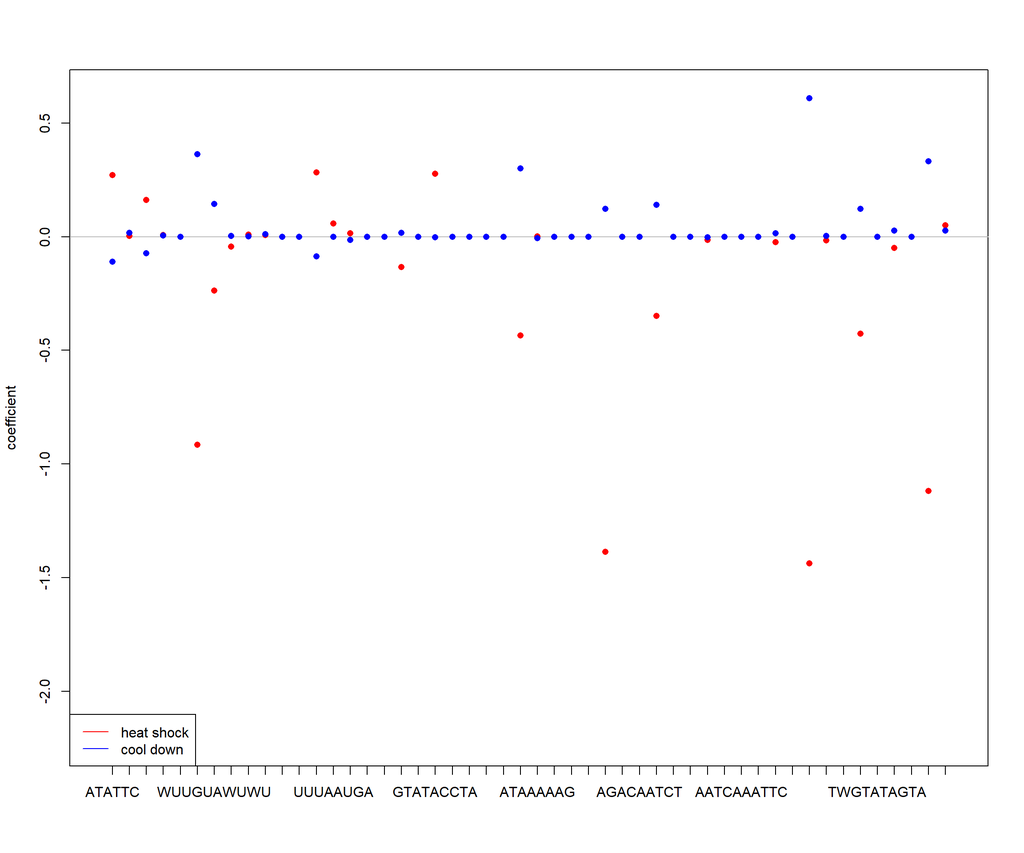

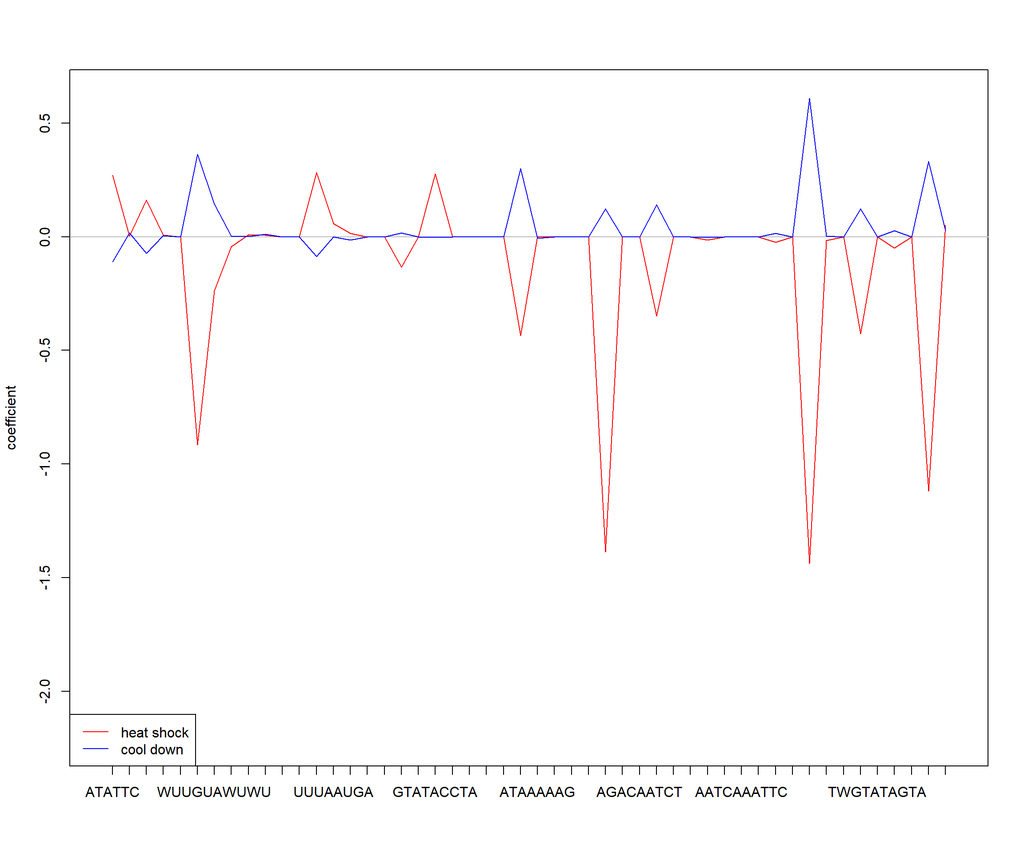

##### compare coefficient of heat shock with and without sorbital - 5min

check if the `additional effect` mension by Gasch is shown in the models. The effect is obvious at first and decrease in 30 mins

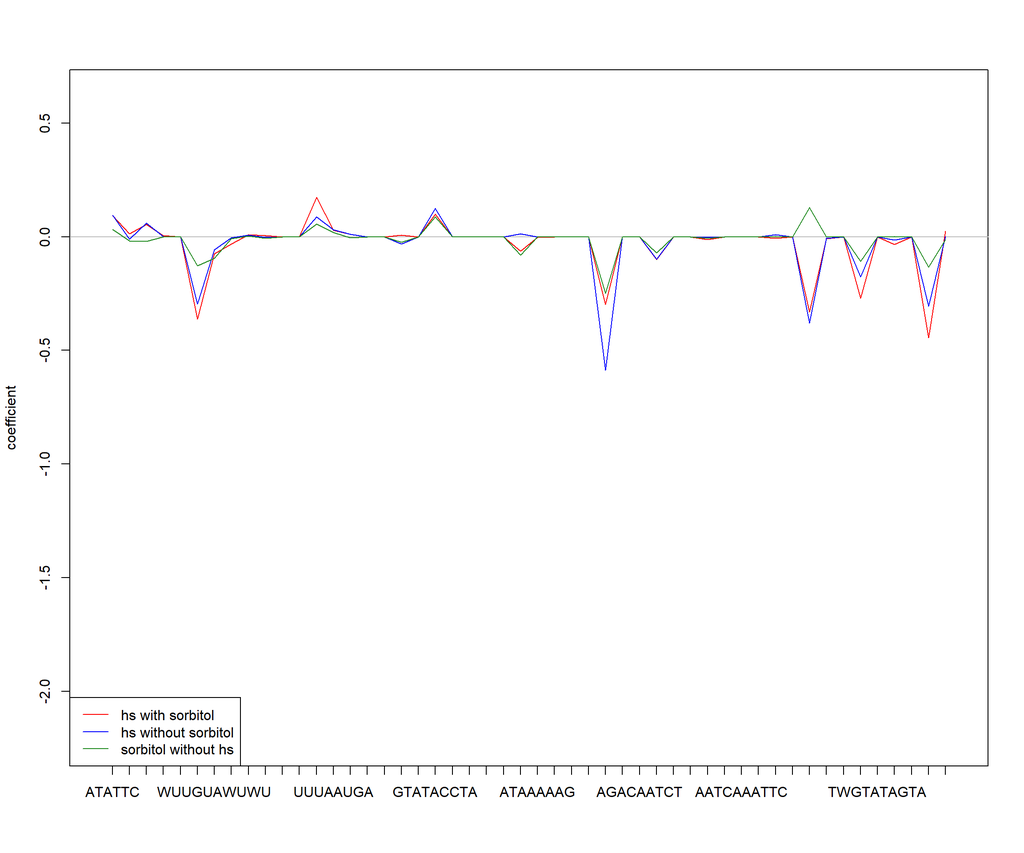

##### compare coefficient of heat shock with and without sorbital - 15min

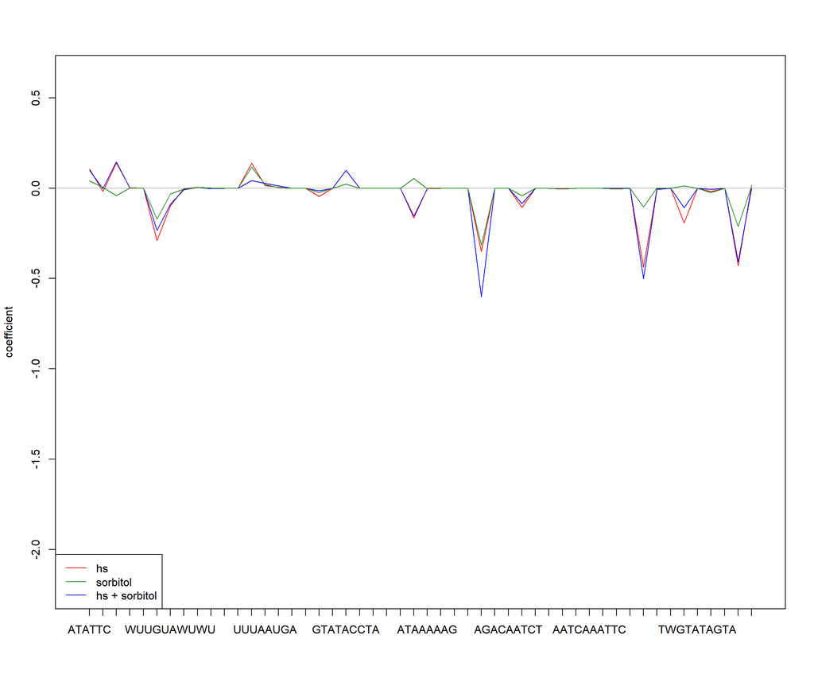

##### compare coefficient of heat shock with and without sorbital - 30min

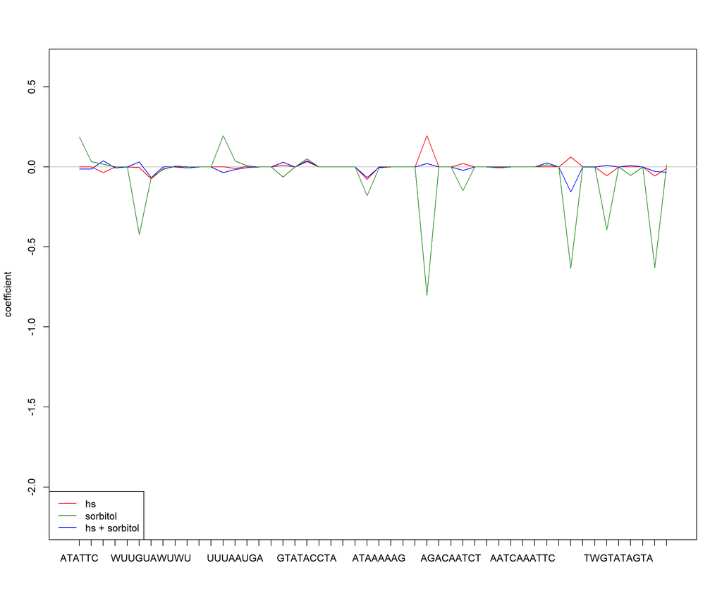

### how to improve model?

- We should solve the problem we have in y’s N/A value. We may fill up the N/A value by comparing other value or adjust the glmnet to ignore data with N/A y value.
- We may need to consider information about position of motifs on RNA
- We may need to consider the coperation between two RNA binding proteins or between RNA binding proteins and secondary structure
- May run cv.glmnet many times to reduce randomness
- more data? (maybe UTR’5)
- should we reflect the motifs and match the sequence?

### how to analyse these models?

- Gasch suggests links between specific **sets of genes** and **specific features** of the experimental conditions. We may check the relationship between them
- compare similar model to make the conclusion more reliable (e.g. heat shock after different time)

### time table

- week 3: Apply basis function to explore if the effect of motifs combination. Analyse the models to quantify how the motifs affect regulation
- week 4: Expand the dataset.
- week 5: prepare for group meeting
- week 6-9: more attempt and improvement
- week 10-11: final report
- week 12-14: final presentations

markdown report: what learning from existing motifs explain what the model tell us about these motifs fitting model - use the model as the central part, indicate how to improve and learning from it feature selection: which motifs make effort